# Quantified Self Movement Data Analysis

Ajani Gyasi

December 26, 2015

## Introduction

Using devices such as Jawbone Up, Nike FuelBand, and Fitbit it is now possible to collect a large amount of data about personal activity relatively inexpensively. Our goal for this project will be to use data from accelerometers on the belt, forearm, arm, and dumbell of 6 participants. They were asked to perform barbell lifts correctly and incorrectly in 5 different ways. We will use this information to predict their exercise results.

## Library & Data Loads

```r
library(caret)
```

```r
library(rpart)
library(rpart.plot)
library(randomForest)
library(corrplot)
trainUrl <-"https://d396qusza40orc.cloudfront.net/predmachlearn/pml-training.csv"
testUrl <- "https://d396qusza40orc.cloudfront.net/predmachlearn/pml-testing.csv"
trainFile <- "./data/pml-training.csv"
testFile  <- "./data/pml-testing.csv"
if (!file.exists("./data")) {
  dir.create("./data")
}
if (!file.exists(trainFile)) {
  download.file(trainUrl, destfile=trainFile)
}
if (!file.exists(testFile)) {
  download.file(testUrl, destfile=testFile)
}


#Read in the data
trainRAW <- read.csv("./data/pml-training.csv")
testRAW <- read.csv("./data/pml-testing.csv")

dim(trainRAW)
```

```
## [1] 19622   160
```

```r
dim(testRAW)
```

```
## [1]  20 160
```

The raw training data has 160 variables and 19,622 observations. The raw testing data also has 160 variables, but only 20 observations.

### Data Cleanse

Let’s clear out the missing data

```r
trainRAW <- trainRAW[, colSums(is.na(trainRAW)) == 0]
testRAW <- testRAW[, colSums(is.na(testRAW)) == 0]

#Remove distracting columns in the data
classe <- trainRAW$classe
trainRM <- grepl("^X|timestamp|window", names(trainRAW))
trainRAW <- trainRAW[, !trainRM]
training <- trainRAW[, sapply(trainRAW, is.numeric)]
training$classe <- classe

testRM <- grepl("^X|timestamp|window", names(testRAW))
testRAW <- testRAW[, !testRM]
testing <- testRAW[, sapply(testRAW, is.numeric)]

dim(training)
```

```
## [1] 19622    53
```

```r
dim(testing)
```

```
## [1] 20 53
```

The cleasned training & testing data sets both contain 53 variables with the same amount of observations as it did in the raw data sets.

# Split Training data into Cross-Validation data set

We will make a 70/30 split in our cleansed Training data set

```r
set.seed(666)
inTrain <- createDataPartition(y=training$classe, p=0.70, list = F)
trainData <- training[inTrain,]
cvData <- training[-inTrain,]
```

## Modeling the Data

The **Random Forest** will be our algorithm of choice to fit a predictive model due to its autonomy in variable selection and it will provide insight on correlated covariates and outliers. We will also use **5-fold cross validation** to resample.

```r
fiveFold <- trainControl(method = "cv", 5)
modelRf <- train(classe ~., data = trainData, method = "rf", trControl = fiveFold, ntree = 250)
modelRf
```

```
## Random Forest
##
## 13737 samples
##    52 predictor
##     5 classes: 'A', 'B', 'C', 'D', 'E'
##
## No pre-processing
## Resampling: Cross-Validated (5 fold)
## Summary of sample sizes: 10990, 10989, 10990, 10989, 10990
## Resampling results across tuning parameters:
##
##   mtry  Accuracy   Kappa      Accuracy SD  Kappa SD
##    2    0.9900270  0.9873837  0.001399888  0.001770843
##   27    0.9916284  0.9894097  0.001338086  0.001693650
##   52    0.9827469  0.9781745  0.003373840  0.004269169
##
## Accuracy was used to select the optimal model using  the largest value.
## The final value used for the model was mtry = 27.
```

## Results

Let’s look at the performance of our model on the cross-validation data set.

```r
predictRF <- predict(modelRf, cvData)
confusionMatrix(cvData$classe, predictRF)
```

```
## Confusion Matrix and Statistics
##
##           Reference
## Prediction    A    B    C    D    E
##          A 1672    2    0    0    0
##          B    9 1124    6    0    0
##          C    0    2 1022    2    0
##          D    0    0   10  951    3
##          E    0    1    2    7 1072
##
## Overall Statistics
##
##                Accuracy : 0.9925
##                  95% CI : (0.99, 0.9946)
##     No Information Rate : 0.2856
##     P-Value [Acc > NIR] : < 2.2e-16
##
##                   Kappa : 0.9905
##  Mcnemar's Test P-Value : NA
##
## Statistics by Class:
##
##                      Class: A Class: B Class: C Class: D Class: E
## Sensitivity            0.9946   0.9956   0.9827   0.9906   0.9972
## Specificity            0.9995   0.9968   0.9992   0.9974   0.9979
## Pos Pred Value         0.9988   0.9868   0.9961   0.9865   0.9908
## Neg Pred Value         0.9979   0.9989   0.9963   0.9982   0.9994
## Prevalence             0.2856   0.1918   0.1767   0.1631   0.1827
## Detection Rate         0.2841   0.1910   0.1737   0.1616   0.1822
## Detection Prevalence   0.2845   0.1935   0.1743   0.1638   0.1839
## Balanced Accuracy      0.9971   0.9962   0.9909   0.9940   0.9976
```

```r
accuracy <- postResample(predictRF, cvData$classe)
accuracy
```

```
##  Accuracy     Kappa
## 0.9925234 0.9905419
```

```r
outofSE <- 1 - as.numeric(confusionMatrix(cvData$classe, predictRF)$overall[1])
```

```r
results <- predict(modelRf, testing[, -length(names(testing))])
results
```

```
##  [1] B A B A A E D B A A B C B A E E A B B B
## Levels: A B C D E
```

## Appendix: Figures

Decision Tree Visualization

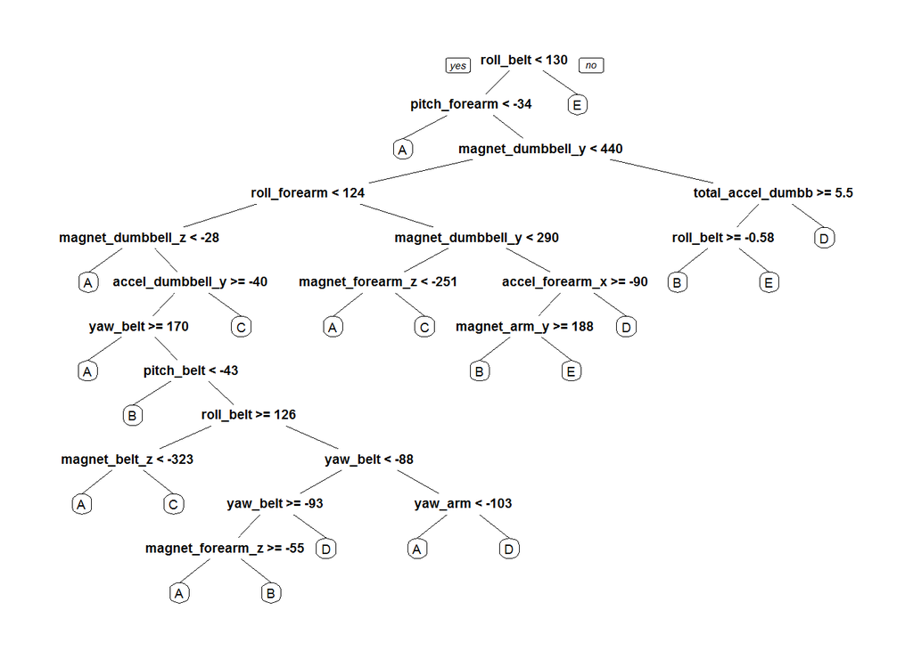

```r
tree <- rpart(classe ~., data = trainData, method = "class")
prp(tree)
```

Correlation Matrix

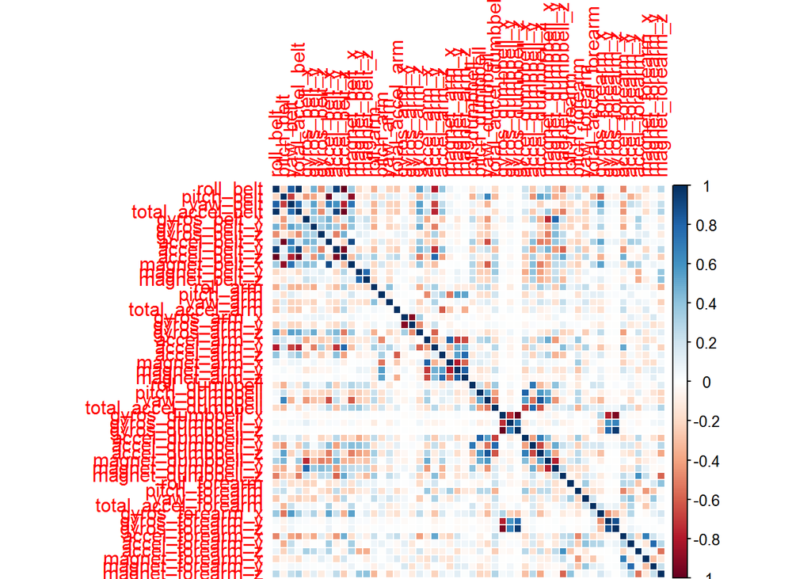

```r
corrPlot <- cor(trainData[, -length(names(trainData))])
corrplot(corrPlot, method = "color")
```